# Fama-French Factor Performance

Roger J. Bos, CFA

as of 2019-12-10

Fama-French Monthly 5 Factor Returns

The following tables show the monthly returns of the five factors for different time periods. You can see that momentum is particularly prone to occasional crashes, following by a strong bounce back.

### Full Period - 1963-07-31 to 2019-10-31

| Size | Value | Investment | Profitability | Momentum |
| --- | --- | --- | --- | --- |
| 0.79 | 1.06 | 0.95 | 0.91 | 1.85 |

### By Decade

| Decade | Size | Value | Investment | Profitability | Momentum |
| --- | --- | --- | --- | --- | --- |
| 1960 | 2.74 | 0.69 | -0.17 | 0.37 | 1.3 |
| 1970 | 1.4 | 2.34 | 1.81 | -0.15 | 0.34 |
| 1980 | -0.09 | 1.74 | 1.66 | 1.4 | 2.46 |
| 1990 | -0.61 | -0.04 | -0.01 | 0.64 | 3.68 |
| 2000 | 2.1 | 2.23 | 1.95 | 2.46 | -0.51 |
| 2010 | -0.16 | -0.76 | 0.06 | 0.53 | 3.65 |

### By Year

| Year | Size | Value | Investment | Profitability | Momentum |
| --- | --- | --- | --- | --- | --- |
| 1963 | -3.33 | 1.45 | -0.94 | 1.54 | 3.82 |
| 1964 | 0.07 | 2.56 | 1.75 | -0.75 | 3.35 |
| 1965 | 5.9 | 1.71 | -0.9 | -0.1 | 2.91 |
| 1966 | 0.97 | -0.22 | -0.14 | -0.11 | -3.8 |
| 1967 | 10.42 | -1.26 | -3.34 | 1.76 | 6.36 |
| 1968 | 6.47 | 4.2 | 3.42 | -2.87 | 2.59 |
| 1969 | -4.35 | -3.22 | -1.41 | 3.71 | -4.89 |
| 1970 | -3.15 | 6.21 | 6.89 | -0.64 | -1.19 |
| 1971 | 1.75 | -2.68 | -1.45 | 2.33 | 3.38 |
| 1972 | -2.87 | 0.67 | -0.59 | 1.87 | 3.51 |
| 1973 | -6.84 | 6.46 | 2.52 | -3.49 | -7.68 |
| 1974 | 0.14 | 3.24 | 8.28 | -1.57 | -10.76 |
| 1975 | 4.35 | 2.24 | 0.07 | -0.01 | 8.31 |
| 1976 | 4.62 | 5.62 | 1.81 | -1.55 | 5.79 |
| 1977 | 6.71 | 2.08 | -0.06 | 0.52 | -2.24 |
| 1978 | 4.21 | -0.3 | 0.96 | 1.52 | 0.73 |
| 1979 | 5.11 | -0.16 | -0.37 | -0.46 | 3.57 |
| 1980 | 1.56 | -5.84 | -2.6 | 3.17 | 5.86 |
| 1981 | 2.26 | 6.71 | 2.84 | -0.43 | -4.73 |
| 1982 | 1.75 | 2.78 | 4.09 | -1.02 | 3.17 |
| 1983 | 2.87 | 4.5 | 3.68 | 0.09 | 3.62 |
| 1984 | -2.44 | 5.43 | 1.05 | 4.34 | -1.38 |
| 1985 | -0.03 | 0.14 | -0.79 | 2.55 | 6.31 |
| 1986 | -2.77 | 2.33 | 2.45 | 1.96 | 3.05 |
| 1987 | -2.64 | -1.07 | 1.78 | 1.78 | 0.29 |
| 1988 | 1.63 | 3.5 | 2.28 | 0.83 | 3.13 |
| 1989 | -3.08 | -1.03 | 1.79 | 0.7 | 5.24 |
| 1990 | -4.43 | -3.42 | -0.19 | 2.57 | -3.53 |
| 1991 | 3.46 | -3.17 | -3.3 | 2.57 | 7.47 |
| 1992 | 2.45 | 5.97 | 1.74 | 1.82 | 1.77 |
| 1993 | 1.62 | 4.75 | 3.01 | -2.23 | 2.29 |
| 1994 | -0.76 | -0.21 | 1.12 | 1.84 | -1.02 |
| 1995 | -1.73 | 1.12 | 0.61 | 0.37 | 7.63 |
| 1996 | -0.52 | 1.26 | -0.02 | 3.76 | 4.28 |
| 1997 | -1.39 | 3.77 | 1.01 | 2.44 | 6.75 |
| 1998 | -7.06 | -2.5 | -1.49 | -0.21 | 5.71 |
| 1999 | 2.26 | -7.95 | -2.6 | -6.53 | 5.5 |
| 2000 | 1.96 | 10.47 | 10.1 | 6.78 | -4.76 |
| 2001 | 7.14 | 4.79 | 2.76 | 5.02 | -3.95 |
| 2002 | 2.08 | 2.51 | 5.41 | 6.72 | -6.72 |
| 2003 | 5.19 | 1.13 | 3.51 | -4.48 | 7.94 |
| 2004 | 2.06 | 2.04 | -1.88 | 1.84 | 3.02 |
| 2005 | -0.02 | 2.21 | -1.38 | 0.39 | 0.95 |
| 2006 | 0.57 | 3.45 | 2.01 | 0.45 | 2.86 |
| 2007 | -2.21 | -4.17 | -2.19 | 1.16 | 0.4 |
| 2008 | 1.92 | 0.69 | 1.61 | 6.46 | -12.76 |
| 2009 | 2.3 | -0.78 | -0.44 | 0.29 | 7.91 |
| 2010 | 3.52 | -1.02 | 2.58 | -0.4 | 5.17 |
| 2011 | -1.34 | -2.43 | -0.25 | 3.61 | 0.48 |
| 2012 | 0.05 | 2.37 | 2.24 | -1.27 | 4.53 |
| 2013 | 1.69 | 0.4 | 0.29 | -0.99 | 8.91 |
| 2014 | -1.96 | -0.49 | -0.48 | 0.21 | 3.31 |
| 2015 | -1.67 | -2.92 | -2.6 | 0.14 | 0.25 |
| 2016 | 2.56 | 5.63 | 2.4 | 1.09 | 3.79 |
| 2017 | -1.37 | -3.32 | -2.83 | 1.69 | 5.65 |
| 2018 | -1.42 | -3.02 | 0.02 | -0.5 | -1.69 |
| 2019 | -1.93 | -3.21 | -0.9 | 1.9 | 6.57 |

#### The following table divides the factor returns into periods on recesssion (indicated by a 1) and non-recession (indicated by a 0), as determined by the [NBER](https://www.nber.org/cycles.html). Here are the actual recession dates:

| From | Through |
| --- | --- |
| 1969-12-01 | 1970-11-30 |
| 1973-11-01 | 1975-03-31 |
| 1980-01-01 | 1980-07-31 |
| 1981-07-01 | 1982-11-30 |
| 1990-07-01 | 1991-03-31 |
| 2001-03-01 | 2001-11-30 |
| 2007-12-01 | 2009-06-30 |

#### Factor Performance Conditional on Recession - 1963-07-31 to 2019-10-31

| recession | Size | Value | Investment | Profitability | Momentum |
| --- | --- | --- | --- | --- | --- |
| 0 | 0.85 | 0.94 | 0.7 | 0.85 | 2.57 |
| 1 | 0.36 | 1.83 | 2.57 | 1.29 | -2.85 |

### Monthly Data

#### Average Performance of all 5 Factors

| Yield Curve | Pre-GFC | Post-GFC |
| --- | --- | --- |
| Steepens > 5 bps | 0.6175694 | 2.2927221 |
| Flattens > 5 bps | 1.3482933 | -0.234589 |

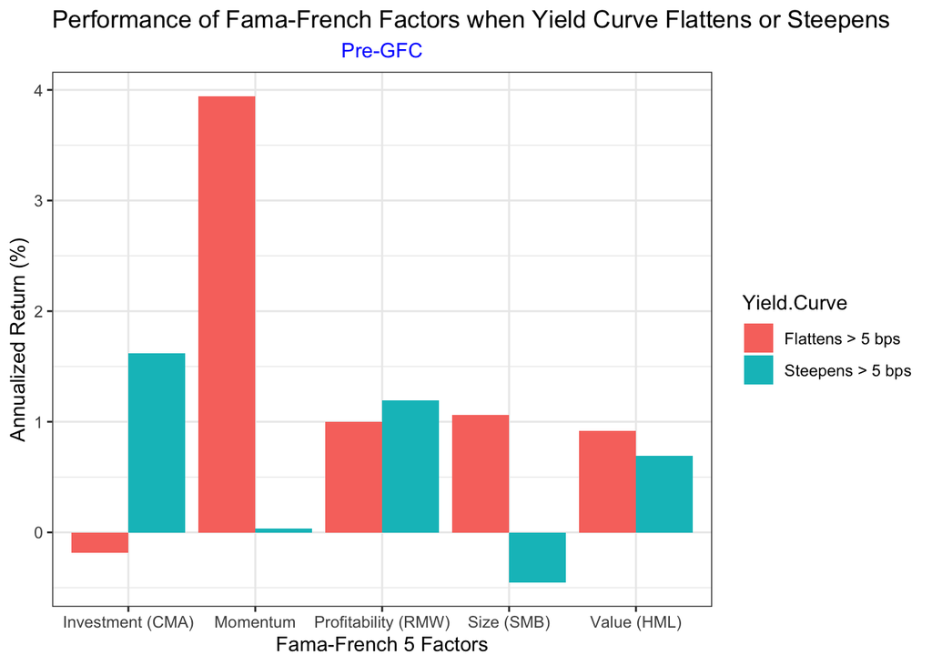

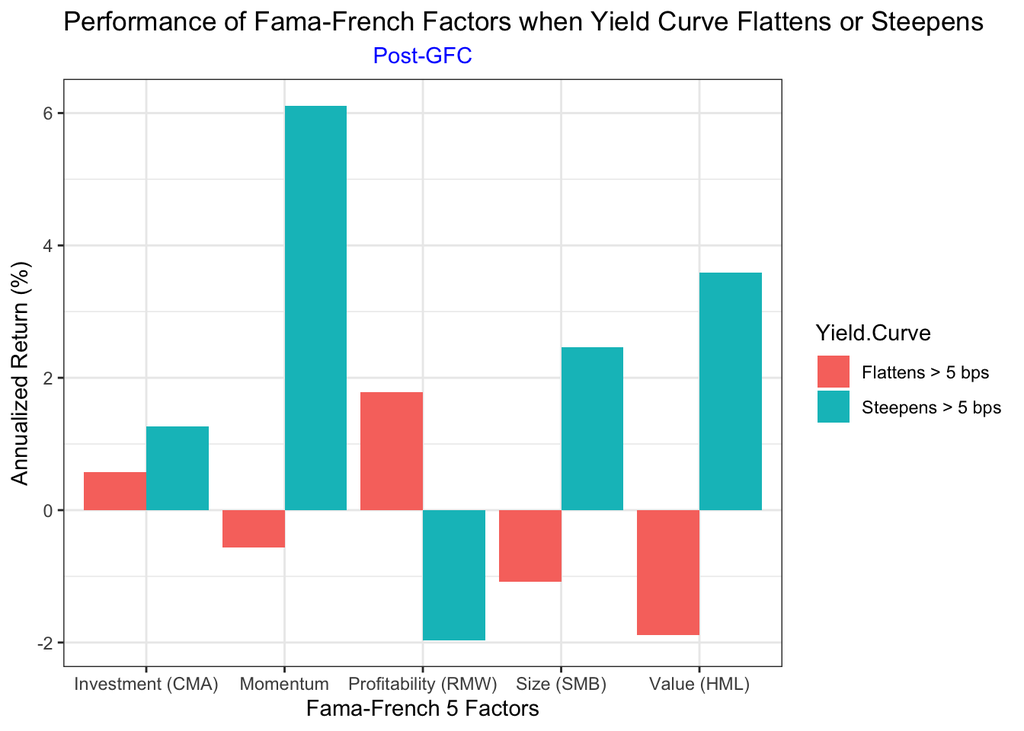

Notes: Pre-GFC is from January 1990 - December 2007. Post-GFC is from July 2009 - May 2019.

Sources: The Fama-French factors can be downloaded from the [Kenneth R. French Data Library](https://mba.tuck.dartmouth.edu/pages/faculty/ken.french/). The slope of the yield curve is measured by the spread between the 10-year and 2-year Treasury yields, FRED data codes T10Y2YM and T10Y2Y.